# W207 Final Lab - EDA

Michael Winton

7/7/2018

## Load school data

```r
schools <- read.csv('2016 School Explorer.csv')
summary(schools[,1:41])  # non-grade-specific columns
```

```
##  Adjusted.Grade New.     Other.Location.Code.in.LCGMS
##   :1270          :1245         :1271
##  x:   2         x:  27   75k372:   1
##
##
##
##
##
##                                                                          School.Name
##  P.S. 212                                                                      :   2
##  P.S. 253                                                                      :   2
##  A.C.E. ACADEMY FOR SCHOLARS AT THE GERALDINE FERRARO CAMPUS                   :   1
##  ACADEMIC LEADERSHIP CHARTER SCHOOL                                            :   1
##  ACADEMY FOR COLLEGE PREPARATION AND CAREER EXPLORATION: A COLLEGE BOARD SCHOOL:   1
##  ACADEMY FOR NEW AMERICANS                                                     :   1
##  (Other)                                                                       :1264
##     SED.Code         Location.Code     District        Latitude
##  Min.   :3.075e+11   01M015 :   1   Min.   : 1.00   Min.   :40.51
##  1st Qu.:3.209e+11   01M019 :   1   1st Qu.: 9.00   1st Qu.:40.67
##  Median :3.315e+11   01M020 :   1   Median :15.00   Median :40.72
##  Mean   :3.287e+11   01M034 :   1   Mean   :16.14   Mean   :40.73
##  3rd Qu.:3.424e+11   01M063 :   1   3rd Qu.:24.00   3rd Qu.:40.82
##  Max.   :3.531e+11   01M064 :   1   Max.   :32.00   Max.   :40.90
##                      (Other):1266
##    Longitude                                Address..Full.
##  Min.   :-74.24   100 W 77TH ST NEW YORK, NY 10024 :   3
##  1st Qu.:-73.96   1000 TELLER AVE BRONX, NY 10456  :   3
##  Median :-73.92   108-35 167TH ST JAMAICA, NY 11433:   3
##  Mean   :-73.92   125 E 181ST ST BRONX, NY 10453   :   3
##  3rd Qu.:-73.88   154 W 93RD ST NEW YORK, NY 10025 :   3
##  Max.   :-73.71   1827 ARCHER ST BRONX, NY 10460   :   3
##                   (Other)                          :1254
##             City          Zip                                  Grades
##  BROOKLYN     :411   Min.   :10001   PK,0K,01,02,03,04,05         :400
##  BRONX        :297   1st Qu.:10452   06,07,08                     :264
##  NEW YORK     :232   Median :11203   0K,01,02,03,04,05            :207
##  STATEN ISLAND: 60   Mean   :10816   0K,01,02,03,04,05,06,07,08   : 89
##  JAMAICA      : 32   3rd Qu.:11232   PK,0K,01,02,03,04,05,06,07,08: 85
##  FLUSHING     : 30   Max.   :11694   06,07,08,09,10,11,12         : 81
##  (Other)      :210                   (Other)                      :146
```

[output cut: 73 more lines]

```
##  92%    :107   Approaching Target:208   Approaching Target:302
##  93%    :107   Exceeding Target  :364   Exceeding Target  :245
##  94%    :101   Meeting Target    :596   Meeting Target    :633
##  96%    : 97   N/A               : 73   N/A               : 86
##  91%    : 96   Not Meeting Target: 31   Not Meeting Target:  6
##  90%    : 87
##  (Other):677
##  Average.ELA.Proficiency Average.Math.Proficiency
##  N/A    :  55            N/A    :  55
##  2.27   :  30            2.22   :  22
##  2.19   :  23            2.3    :  18
##  2.24   :  21            2.36   :  17
##  2.26   :  21            2.15   :  16
##  2.32   :  21            2.54   :  16
##  (Other):1101            (Other):1128
```

```r
# str(schools)
```

*Thoughts on columns to keep…*

Descriptive Columns:

- School.Name
- Location.Code (join to shsat$DBN)

Possible Explanatory Vars:

- District (integer)
- City (convert to factor)
- Zip (convert to factor)
- Grade.Low (e.g. PK; convert to factor)
- Grade.High (e.g. 12; convert to factor)
- Community.School (Yes/No; convert to factor)
- Economic.Need.Index (decimal)
- School.Income.Estimate (consider binning)
- Percent.ELL (convert to decimal)
- Percent.Asian (convert to decimal)
- Percent.Black (convert to decimal)
- Percent.Hispanic (convert to decimal)
- Percent.Black…Hispanic (convert to decimal)
- Percent.White (convert to decimal)
- Student.Attendance.Rate (convert to decimal)
- Percent.of.Students.Chronically.Absent (convert to decimal)
- Rigorous.Instruction.. (convert to decimal)
- Collaborative.Teachers.. (convert to decimal)
- Supportive.Environment.. (convert to decimal)
- Effective.School.Leadership.. (convert to decimal)
- Strong.Family.Community.Ties.. (convert to decimal)
- Trust.. (convert to decimal)
- Average.ELA.Proficiency (decimal)
- Average.Math.Proficiency (decimal)

Comments: - Common Core columns - we have options for percentages or buckets (both are provided) - Propose ignoring the grade x demographic columns at least in initial model - Dataet has one row per school

## Load SHSAT data

```r
shsat <- read.csv('D5 SHSAT Registrations and Testers.csv')
head(shsat)
```

```
##      DBN              School.name Year.of.SHST Grade.level
## 1 05M046   P.S. 046 Arthur Tappan         2013           8
## 2 05M046   P.S. 046 Arthur Tappan         2014           8
## 3 05M046   P.S. 046 Arthur Tappan         2015           8
## 4 05M046   P.S. 046 Arthur Tappan         2016           8
## 5 05M123 P.S. 123 Mahalia Jackson         2013           8
## 6 05M123 P.S. 123 Mahalia Jackson         2014           8
##   Enrollment.on.10.31 Number.of.students.who.registered.for.the.SHSAT
## 1                  91                                              31
## 2                  95                                              26
## 3                  73                                              21
## 4                  56                                              20
## 5                  62                                              31
## 6                  62                                              25
##   Number.of.students.who.took.the.SHSAT
## 1                                    14
## 2                                     7
## 3                                    10
## 4                                     8
## 5                                    14
## 6                                    13
```

```r
str(shsat)
```

```
## 'data.frame':    140 obs. of  7 variables:
##  $ DBN                                            : Factor w/ 28 levels "05M046","05M123",..: 1 1 1 1 2 2 2 2 3 3 ...
##  $ School.name                                    : Factor w/ 30 levels "Academy for Social Action",..: 20 20 20 20 21 21 21 21 22 22 ...
##  $ Year.of.SHST                                   : int  2013 2014 2015 2016 2013 2014 2015 2016 2013 2014 ...
##  $ Grade.level                                    : int  8 8 8 8 8 8 8 8 8 8 ...
##  $ Enrollment.on.10.31                            : int  91 95 73 56 62 62 62 55 84 55 ...
##  $ Number.of.students.who.registered.for.the.SHSAT: int  31 26 21 20 31 25 12 16 58 23 ...
##  $ Number.of.students.who.took.the.SHSAT          : int  14 7 10 8 14 13 5 5 14 12 ...
```

```r
describe(shsat)
```

```
## shsat
##
##  7  Variables      140  Observations
## ---------------------------------------------------------------------------
## DBN
##        n  missing distinct
##      140        0       28
##
## lowest : 05M046 05M123 05M129 05M148 05M157, highest: 84M384 84M388 84M481 84M709 84M726
## ---------------------------------------------------------------------------
## School.name
##        n  missing distinct
##      140        0       30
##
## lowest : Academy for Social Action                                Academy for Social Action: A College Board School        Choir Academy of Harlem                                  Columbia Secondary School                                Democracy Prep Charter School
## highest: The Urban Assembly Institute for New Technologies        The Urban Assembly School for Global Commerce            Thurgood Marshall Academy for Learning and Social Change Urban Assembly Academy for Future Leaders                Urban Assembly School for the Performing Arts
## ---------------------------------------------------------------------------
## Year.of.SHST
##        n  missing distinct     Info     Mean      Gmd
##      140        0        4    0.937     2015    1.258
##
## Value       2013  2014  2015  2016
## Frequency     33    35    35    37
## Proportion 0.236 0.250 0.250 0.264
## ---------------------------------------------------------------------------
## Grade.level
##        n  missing distinct     Info     Mean      Gmd
##      140        0        2    0.716    8.393   0.4805
##
## Value          8     9
## Frequency     85    55
## Proportion 0.607 0.393
## ---------------------------------------------------------------------------
## Enrollment.on.10.31
##        n  missing distinct     Info     Mean      Gmd      .05      .10
##      140        0       88        1    91.97    44.46    37.95    45.00
##      .25      .50      .75      .90      .95
##    62.75    86.00   113.00   124.20   135.15
##
## lowest :  17  26  27  30  33, highest: 165 273 293 323 344
## ---------------------------------------------------------------------------
## Number.of.students.who.registered.for.the.SHSAT
##        n  missing distinct     Info     Mean      Gmd      .05      .10
##      140        0       48    0.995    19.07    22.84      0.0      0.0
##      .25      .50      .75      .90      .95
##      2.0     12.0     26.0     44.2     74.2
##
## lowest :   0   1   2   3   4, highest:  84  90  94  97 118
## ---------------------------------------------------------------------------
## Number.of.students.who.took.the.SHSAT
##        n  missing distinct     Info     Mean      Gmd      .05      .10
##      140        0       35     0.99    9.664    10.78        0        0
##      .25      .50      .75      .90      .95
##        1        6       14       24       29
##
## lowest :  0  1  2  3  4, highest: 37 38 39 43 45
## ---------------------------------------------------------------------------
```

Comments: - shsat$DBN = schools$Location.Code - data has > 1 row per school - consider aggregrating Year.of.SHST (ranges from 2013-2016) - consider aggregating Grade.level (all are either 8 or 9) - use Enrollment.on.10.31 to normalize the other columns - also consider Enrollment.on.10.31 as an explanatory variable - look at number registered as primary outcome var - also look at % of registered who actually took the test as secondary potential outcome var

## Flatten `shsat` so we have one row per school (for joining)

Logic: - aggregating 8th and 9th graders together - creating separate columns for 2013, 2014, 2015, 2016 - do a full join, so even if some years had no registrations, the school will appear in the result set - use DBN only; dropping school name (2 schools got renamed during this time period)

```r
# drop school name to avoid duplicate rows
tmp <- shsat %>% select(-School.name)

# aggregate Grade.level 8,9 together
tmp <- aggregate(. ~ DBN + Year.of.SHST, tmp, sum)

# drop Grade.level column now that we've aggregated
tmp <- tmp %>% select(-Grade.level)

# rename columns
# drop unnecessary ones
tmp2013 <- tmp %>%
  filter(Year.of.SHST==2013) %>%
  rename(enroll_2013 = Enrollment.on.10.31,
         num_reg_2013 = Number.of.students.who.registered.for.the.SHSAT,
         num_test_2013 = Number.of.students.who.took.the.SHSAT) %>%
  mutate(frac_reg_2013 = num_reg_2013/enroll_2013,
         frac_test_2013 = num_test_2013/num_reg_2013) %>%
  select(-Year.of.SHST)
tmp2014 <- tmp %>%
  filter(Year.of.SHST==2014) %>%
  rename(enroll_2014 = Enrollment.on.10.31,
         num_reg_2014 = Number.of.students.who.registered.for.the.SHSAT,
         num_test_2014 = Number.of.students.who.took.the.SHSAT) %>%
  mutate(frac_reg_2014 = num_reg_2014/enroll_2014,
         frac_test_2014 = num_test_2014/num_reg_2014) %>%
  select(-Year.of.SHST)
tmp2015 <- tmp %>%
  filter(Year.of.SHST==2015) %>%
  rename(enroll_2015 = Enrollment.on.10.31,
         num_reg_2015 = Number.of.students.who.registered.for.the.SHSAT,
         num_test_2015 = Number.of.students.who.took.the.SHSAT) %>%
  mutate(frac_reg_2015 = num_reg_2015/enroll_2015,
         frac_test_2015 = num_test_2015/num_reg_2015) %>%
  select(-Year.of.SHST)
tmp2016 <- tmp %>%
  filter(Year.of.SHST==2016) %>%
  rename(enroll_2016 = Enrollment.on.10.31,
         num_reg_2016 = Number.of.students.who.registered.for.the.SHSAT,
         num_test_2016 = Number.of.students.who.took.the.SHSAT) %>%
  mutate(frac_reg_2016 = num_reg_2016/enroll_2016,
         frac_test_2016 = num_test_2016/num_reg_2016) %>%
  select(-Year.of.SHST)

# join tables, resulting in one row per school
shsat_flat <- tmp2013 %>% full_join(tmp2014) %>% full_join(tmp2015) %>% full_join(tmp2016)
# review joined dataframe
head(shsat_flat)
```

```
##      DBN enroll_2013 num_reg_2013 num_test_2013 frac_reg_2013
## 1 05M046          91           31            14    0.34065934
## 2 05M123          62           31            14    0.50000000
## 3 05M129          84           58            14    0.69047619
## 4 05M157          82            3             1    0.03658537
## 5 05M161         118           10             5    0.08474576
## 6 05M286          60           27            13    0.45000000
##   frac_test_2013 enroll_2014 num_reg_2014 num_test_2014 frac_reg_2014
## 1      0.4516129          95           26             7    0.27368421
## 2      0.4516129          62           25            13    0.40322581
## 3      0.2413793          55           23            12    0.41818182
## 4      0.3333333         103            2             1    0.01941748
## 5      0.5000000         123           26            17    0.21138211
## 6      0.4814815          67           44             9    0.65671642
##   frac_test_2014 enroll_2015 num_reg_2015 num_test_2015 frac_reg_2015
```

[output cut: 20 more lines]

```r
summary(shsat_flat)
```

```
##       DBN      enroll_2013     num_reg_2013  num_test_2013
##  05M046 : 1   Min.   : 37.0   Min.   : 0.0   Min.   : 0.00
##  05M123 : 1   1st Qu.: 68.0   1st Qu.: 9.0   1st Qu.: 5.00
##  05M129 : 1   Median : 91.0   Median :21.0   Median :12.00
##  05M148 : 1   Mean   :124.4   Mean   :26.4   Mean   :12.56
##  05M157 : 1   3rd Qu.:135.0   3rd Qu.:32.0   3rd Qu.:15.00
##  05M161 : 1   Max.   :457.0   Max.   :98.0   Max.   :42.00
##  (Other):22   NA's   :3       NA's   :3      NA's   :3
##  frac_reg_2013     frac_test_2013    enroll_2014     num_reg_2014
##  Min.   :0.00000   Min.   :0.0000   Min.   : 26.0   Min.   :  1.00
##  1st Qu.:0.07035   1st Qu.:0.4194   1st Qu.: 78.5   1st Qu.: 11.25
##  Median :0.14226   Median :0.5000   Median :114.5   Median : 26.00
##  Mean   :0.25306   Mean   :0.5533   Mean   :124.7   Mean   : 32.23
##  3rd Qu.:0.39706   3rd Qu.:0.7537   3rd Qu.:141.0   3rd Qu.: 36.50
##  Max.   :0.98667   Max.   :1.0000   Max.   :401.0   Max.   :118.00
##  NA's   :3         NA's   :4        NA's   :2       NA's   :2
##  num_test_2014   frac_reg_2014     frac_test_2014    enroll_2015
##  Min.   : 0.00   Min.   :0.01389   Min.   :0.0000   Min.   : 38.0
##  1st Qu.: 5.50   1st Qu.:0.08559   1st Qu.:0.2294   1st Qu.: 65.5
##  Median :13.00   Median :0.19290   Median :0.5100   Median : 98.0
##  Mean   :13.35   Mean   :0.30751   Mean   :0.4352   Mean   :121.7
##  3rd Qu.:18.75   3rd Qu.:0.38795   3rd Qu.:0.6346   3rd Qu.:155.5
##  Max.   :46.00   Max.   :1.04225   Max.   :0.7812   Max.   :376.0
##  NA's   :2       NA's   :2         NA's   :2        NA's   :2
##   num_reg_2015   num_test_2015   frac_reg_2015     frac_test_2015
##  Min.   : 0.00   Min.   : 0.00   Min.   :0.00000   Min.   :0.1538
##  1st Qu.: 7.50   1st Qu.: 5.25   1st Qu.:0.06232   1st Qu.:0.4940
##  Median :18.50   Median :10.00   Median :0.16345   Median :0.7362
##  Mean   :22.96   Mean   :13.12   Mean   :0.24915   Mean   :0.6602
##  3rd Qu.:28.00   3rd Qu.:21.50   3rd Qu.:0.27262   3rd Qu.:0.8523
##  Max.   :84.00   Max.   :40.00   Max.   :1.00000   Max.   :1.0000
##  NA's   :2       NA's   :2       NA's   :2         NA's   :4
##   enroll_2016     num_reg_2016   num_test_2016  frac_reg_2016
##  Min.   : 33.0   Min.   : 0.00   Min.   : 0.0   Min.   :0.00000
##  1st Qu.: 64.5   1st Qu.:10.50   1st Qu.: 6.0   1st Qu.:0.05561
##  Median :111.0   Median :17.50   Median :10.5   Median :0.15302
##  Mean   :129.2   Mean   :22.12   Mean   :13.5   Mean   :0.22694
##  3rd Qu.:166.0   3rd Qu.:29.00   3rd Qu.:18.5   3rd Qu.:0.29509
##  Max.   :406.0   Max.   :90.00   Max.   :53.0   Max.   :0.96774
##  NA's   :2       NA's   :2       NA's   :2      NA's   :2
##  frac_test_2016
##  Min.   :0.2308
##  1st Qu.:0.5074
##  Median :0.7573
##  Mean   :0.6700
##  3rd Qu.:0.8705
##  Max.   :0.9412
##  NA's   :6
```

```r
# describe(shsat_flat)
```

*NOTE: there are only 28 distinct schools in this dataset vs. 1272 in the first dataset. So, as a first pass classification, we could simply classify as a “success” based on existence of data in the second dataset for the school (meaning they register at least some kids for the SHSAT test).*

Next, look at histograms of the numeric columns in this dataframe in case we want to further classify (e.g. high vs. low % registration).

### Plot histograms

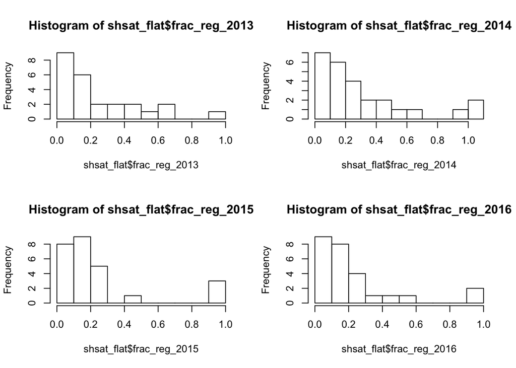

```r
# fraction of students registered
par(mfrow=c(2,2))
hist(shsat_flat$frac_reg_2013, breaks=10)
hist(shsat_flat$frac_reg_2014, breaks=10)
hist(shsat_flat$frac_reg_2015, breaks=10)
hist(shsat_flat$frac_reg_2016, breaks=10)
```

Observations: - Based on histograms, I’d consider classifying into 3 bins: Low (<0.3), Med(0.3-0.8), High(>0.8)

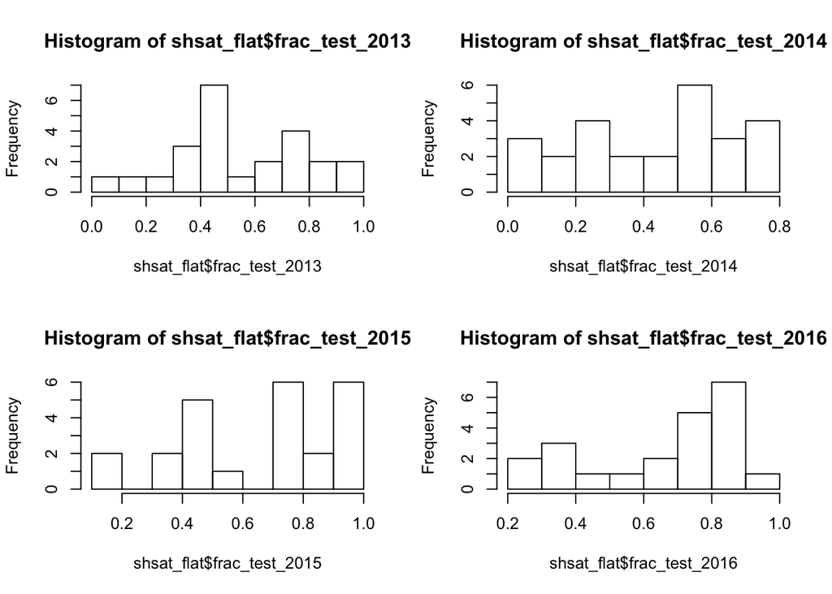

```r
# fraction of students who registered that actually take the test
par(mfrow=c(2,2))
hist(shsat_flat$frac_test_2013, breaks=10)
hist(shsat_flat$frac_test_2014, breaks=10)
hist(shsat_flat$frac_test_2015, breaks=10)
hist(shsat_flat$frac_test_2016, breaks=10)
```

Observations: - Based on histograms, I’d consider classifying into 2 bins: Low (<0.6), High(>0.6) - Getting kids to show up for the test doesn’t appear to be quite as problematic as getting them to register